# Mixed Models

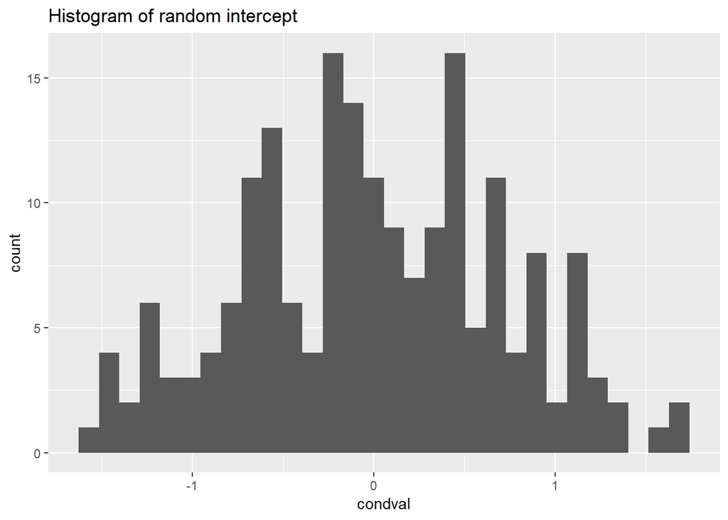

```r
ggplot(ran.d, aes(condval)) +
  geom_histogram(bins = 30) +
  ggtitle("Histogram of random intercept")
```

Next, we might check the distributional assumptions. We already have some information on this from the histograms, but QQ plots are helpful as well. The QQ plots indicate only very modest non-normality, but it is not too extreme and probably close enough for inference.

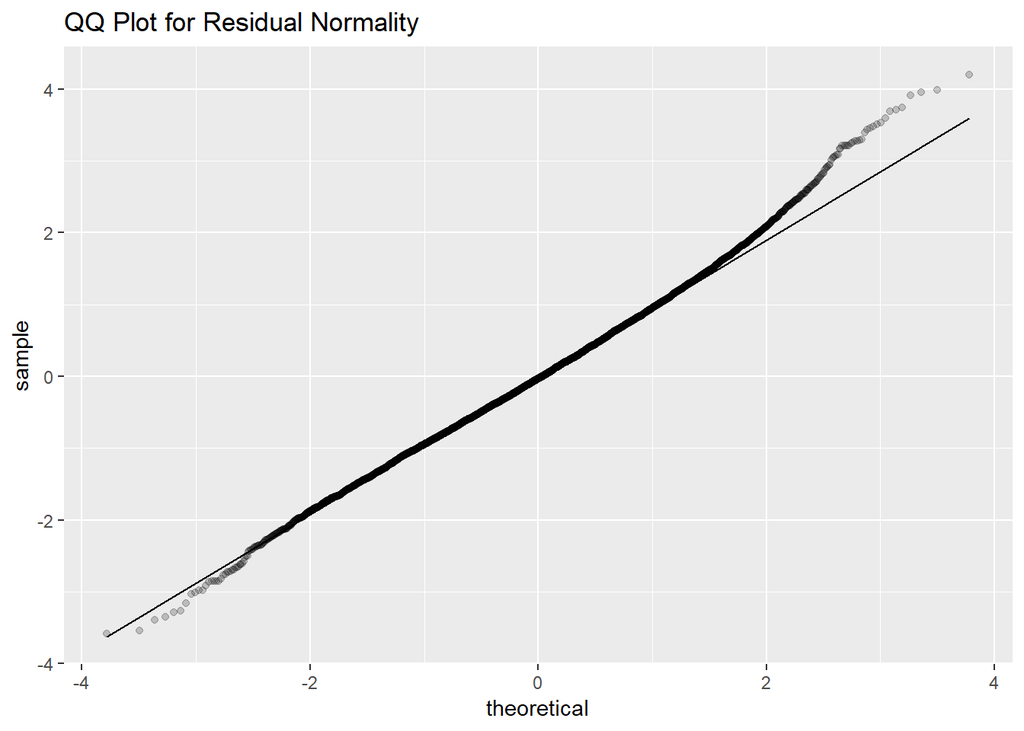

```r
ggplot(res.d, aes(sample = Residuals)) +
  stat_qq(alpha=.2) + stat_qq_line() +
  ggtitle("QQ Plot for Residual Normality")
```

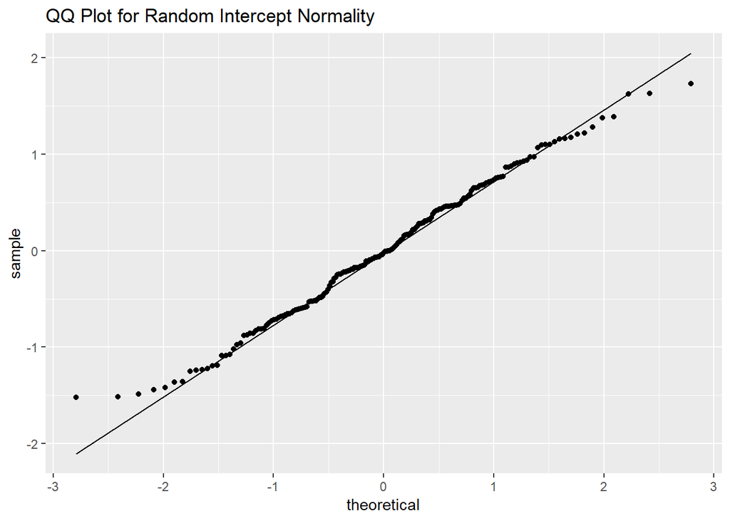

```r
ggplot(ran.d, aes(sample = condval)) +
  stat_qq() + stat_qq_line() +
  ggtitle("QQ Plot for Random Intercept Normality")
```

Finally, we check the homogeneity of variance. The residuals show a characteristic banding when there are floor and ceiling effects. At low predicted values (particularly below 1), positive affect cannot be any lower than 1, so you *must* have positive residuals. At high predicted values, positive affect cannot be greater than 5 so you have small positive or negative residuals. This is responsible for the straight, angled lines at the extremes. Its not particularly clear whether the residual variance changes much across levels of the predited value (Yhat) so its not terrible evidence against homogeneity of variance. Unless easy alternatives were available (they are not) one would probably proceed.

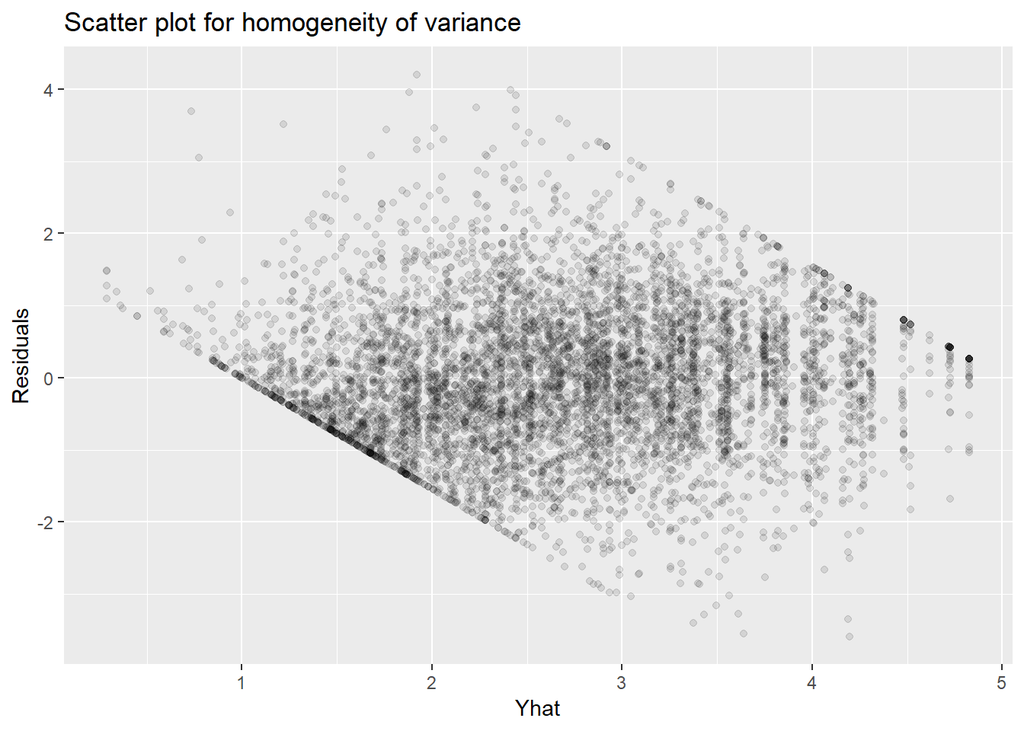

```r
ggplot(res.d, aes(Yhat, Residuals)) +
  geom_point(alpha = .1) +
  ggtitle("Scatter plot for homogeneity of variance")
```